# Git and GitHub

Git and GitHub are used often in programming.

More has been written on these topics than I ever could. Here are some great resources to start using Git in R.

## Intro Video to Git: Alice Bartlett

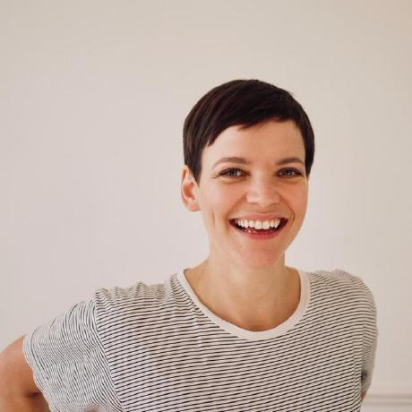

Links: [Video](https://www.youtube.com/watch?v=eWxxfttcMts) - [Slides](https://speakerdeck.com/alicebartlett/git-for-humans)

Bartlett provides a high level introduction to Git and GitHub aimed at a non-programmer. She explains how Git is useful for:

> 1. Telling the story of your project
> 2. Traveling back in time
> 3. Experimenting with changes
> 4. Backing up your work
> 5. Collaborating on projects

She notes that jargon in Git makes it inaccessible to new users. She provides this excellent summary of Git terminology.

> | Git Jargon | Definition |
> | --- | --- |
> | Repository | your project folder |
> | Commit | a snapshot of your repo |
> | Hash | an id for a commit |
> | Checkout | time travel to a specific commit |
> | Branch | a movable label that points to a commit |
> | Merge | combining two branches |
> | Remote | a computer with the repository on it |
> | Clone | get the repository from the remote for the first time |
> | Push | send commits to a remote |
> | Pull | get commits from a remote |

## How to Use Git/GitHub with R

Getting started with Git in R has a bit of a learning curve. There are some nuts-and-bolts that must be tended to before integrating Git with R. Thankfully Dave has posted an excellent walkthrough for Git in RStudio that covers the following:

- Installing Git
- Configuring Git
- Initializing a Git Repository
- Viewing Commit History
- Making a Commit and Viewing More History
- Connecting RStudio and GitHub
- Signing Up for GitHub
- Creating a Personal Access Token (PAT) on GitHub
- Storing Personal Access Token to Connect RStudio and GitHub
- Connecting RStudio Projects with GitHub Repositories
  - RStudio First
  - GitHub First
- General Workflow
  - Push
  - Pull

## Further Reading

1. Hester, Jenny Bryan, the STAT 545 TAs, Jim. Let’s Git Started | Happy Git and GitHub for the UseR. happygitwithr.com, https://happygitwithr.com/. Accessed 30 Jan. 2023.